# Course Project - Practical Machine Learning

Ilse Beldman

2 januari 2017

## Introduction

Using devices such as Jawbone Up, Nike FuelBand, and Fitbit it is now possible to collect a large amount of data about personal activity relatively inexpensively. These type of devices are part of the quantified self movement - a group of enthusiasts who take measurements about themselves regularly to improve their health, to find patterns in their behavior, or because they are tech geeks. One thing that people regularly do is quantify how much of a particular activity they do, but they rarely quantify how well they do it. In this project, your goal will be to use data from accelerometers on the belt, forearm, arm, and dumbell of 6 participants. They were asked to perform barbell lifts correctly and incorrectly in 5 different ways. More information is available from the website here: http://groupware.les.inf.puc-rio.br/har (see the section on the Weight Lifting Exercise Dataset).

## Data

It’s time to load both the training and test data.

```r
# Load both the training and test data and replace all missing values with "NA"
trainSet <- read.csv("C:\\Users\\ibeldman\\AppData\\Local\\Temp\\RtmpKWhWSI\\data25e07a1f6ff7", header=TRUE, na.strings=c("NA","#DIV/0!", ""))
testset <- read.csv("C:\\Users\\ibeldman\\AppData\\Local\\Temp\\RtmpKWhWSI\\data25e032d5676f", header=TRUE, na.strings=c("NA","#DIV/0!", ""))

# Delete columns with all missing values
trainSet<-trainSet[,colSums(is.na(trainSet)) == 0]
testset <-testset[,colSums(is.na(testset)) == 0]

# Delete variables that are not useful
trainSet<-trainSet[,-c(1:7)]
testset<-testset[,-c(1:7)]
```

```r
# Dimensions
dim(trainSet)
dim(testset)
head(trainSet)
head(testset)
```

[output not shown]

## Model

The goal is to predict the variable “Classe” from the data. The variable is a factor variable with five levels. The levels represent the five different ways to perform barbell lifts: * Class A: exactly according to the specification * Class B: throwing the elbows to the front * Class C: lifting the dumbbell only halfway * Class D: lowering the dumbbell only halfway * Class E: throwing the hips to the front People who do a specific repetition are executing Class A are doing the movement in the right way. Movements from the other classes are mistakes. The final model should be accurate and have a minimal out of sample error. This report compares two different algorithms: decision tree and random forest.

Before building the model the required packages needs to be installed en in order to guarantee reproduceability the seed need to be set.

```r
##Installing packages
#install.packages("caret")
#install.packages("randomForest")
#install.packages("rpart")
#install.packages("rpart.plot")
library(caret)
library(randomForest)
library(rpart)
library(rpart.plot)
##Set the seed
set.seed(1234)
```

## Cross Validation

Cross-validation needs to be used and means random subsampling without replacement of the original data set. The result is a subTrain data set (75% of the original set) and subTest data (25%). Fitting is done by applying the two algorithms on the subTrain data set. And of course, testing can be executed by applying the model on the subTest data set.

```r
subsamples <- createDataPartition(y=trainSet$classe, p=0.75)[[1]]
subTrain <- trainSet[subsamples,]
subTest <- trainSet[-subsamples,]
```

Let ’s make a bar plot of the subTrain set.

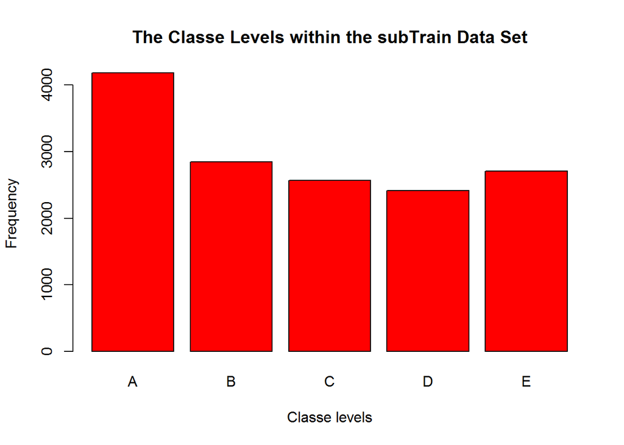

```r
plot(subTrain$classe, col="red", main="The Classe Levels within the subTrain Data Set", xlab="Classe levels", ylab="Frequency")
```

As one can observe the classe level A shows the most occurences within the subTrain data set.

## Decision Tree Model

Decision Tree algorithm is created by the following code:

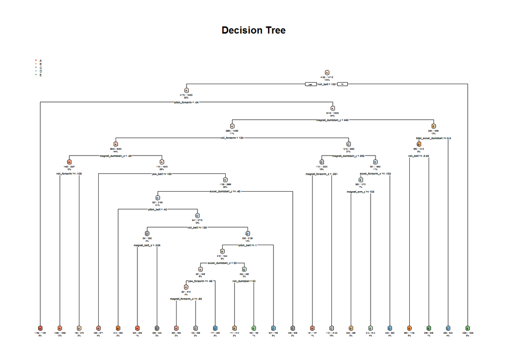

```r
#Create a model with the subTrain data set
DTmodel <- rpart(classe ~ ., data=subTrain, method="class")

# Use the subTest data set to predict
predDTmodel <- predict(DTmodel, subTest, type = "class")

# Plot of the Decision Tree
rpart.plot(DTmodel, main="Decision Tree", extra=102, under=TRUE, faclen=0)
```

## Random Forest Model

```r
#Create a model with the subTrain data set
RFmodel <- randomForest(classe ~. , data=subTrain, method="class")

# Use the subTest data set to predict
predRFmodel <- predict(RFmodel, subTest, type = "class")
```

## Expected Out of Sample Error

The expected out of sample error is a metric of the function 1 minus Accuracy or the ratio between the expected number of missclassified observations and the total number of observations. This will follow from the subTest set.

```r
## Accuracy Decision Tree
confusionMatrix(predDTmodel, subTest$classe)
```

```
## Confusion Matrix and Statistics
##
##           Reference
## Prediction    A    B    C    D    E
##          A 1235  157   16   50   20
##          B   55  568   73   80  102
##          C   44  125  690  118  116
##          D   41   64   50  508   38
##          E   20   35   26   48  625
##
## Overall Statistics
##
##                Accuracy : 0.7394
##                  95% CI : (0.7269, 0.7516)
##     No Information Rate : 0.2845
##     P-Value [Acc > NIR] : < 2.2e-16
##
##                   Kappa : 0.6697
##  Mcnemar's Test P-Value : < 2.2e-16
##
## Statistics by Class:
##
##                      Class: A Class: B Class: C Class: D Class: E
## Sensitivity            0.8853   0.5985   0.8070   0.6318   0.6937
## Specificity            0.9307   0.9216   0.9005   0.9529   0.9678
## Pos Pred Value         0.8356   0.6469   0.6313   0.7247   0.8289
## Neg Pred Value         0.9533   0.9054   0.9567   0.9296   0.9335
## Prevalence             0.2845   0.1935   0.1743   0.1639   0.1837
## Detection Rate         0.2518   0.1158   0.1407   0.1036   0.1274
## Detection Prevalence   0.3014   0.1790   0.2229   0.1429   0.1538
## Balanced Accuracy      0.9080   0.7601   0.8537   0.7924   0.8307
```

```r
## Accuracy Random Forest
confusionMatrix(predRFmodel, subTest$classe)
```

```
## Confusion Matrix and Statistics
##
##           Reference
## Prediction    A    B    C    D    E
##          A 1394    3    0    0    0
##          B    1  944   10    0    0
##          C    0    2  843    6    0
##          D    0    0    2  798    0
##          E    0    0    0    0  901
##
## Overall Statistics
##
##                Accuracy : 0.9951
##                  95% CI : (0.9927, 0.9969)
##     No Information Rate : 0.2845
##     P-Value [Acc > NIR] : < 2.2e-16
##
##                   Kappa : 0.9938
##  Mcnemar's Test P-Value : NA
##
## Statistics by Class:
##
##                      Class: A Class: B Class: C Class: D Class: E
## Sensitivity            0.9993   0.9947   0.9860   0.9925   1.0000
## Specificity            0.9991   0.9972   0.9980   0.9995   1.0000
## Pos Pred Value         0.9979   0.9885   0.9906   0.9975   1.0000
## Neg Pred Value         0.9997   0.9987   0.9970   0.9985   1.0000
## Prevalence             0.2845   0.1935   0.1743   0.1639   0.1837
## Detection Rate         0.2843   0.1925   0.1719   0.1627   0.1837
## Detection Prevalence   0.2849   0.1947   0.1735   0.1631   0.1837
## Balanced Accuracy      0.9992   0.9960   0.9920   0.9960   1.0000
```

## Prepare Submission

```r
#  Writing files for submission
pml_write_files = function(x){
n = length(x)
for(i in 1:n){
filename = paste0("problem_id_",i,".txt")
write.table(x[i],file=filename,quote=FALSE,row.names=FALSE,col.names=FALSE)
}
}
#  Random Forest Model with testset
results <- predict(DTmodel, newdata=testset, type="class")
results
```

```
##  1  2  3  4  5  6  7  8  9 10 11 12 13 14 15 16 17 18 19 20
##  C  A  B  D  A  C  D  A  A  A  C  B  C  A  E  E  A  B  B  B
## Levels: A B C D E
```

```r
pml_write_files(results)
```